# Algae albedo model

```r
library(tidyverse)
library(here)
library(broom)
library(readxl)
library(ggpubr)
library(cowplot)
```

```r
# field radiometer data convolved to albedo
albedo <- read_csv(here("data/radiometer/as_bb_albedo.csv"), col_types = cols())
v_albedo <- read_csv(here("data/radiometer/as_viz_albedo.csv"), col_types = cols()) # visible albedo
nir_albedo <- read_csv(here("data/radiometer/as_nir_albedo.csv"), col_types = cols()) # NIR albedo

# algae abundance (data processed in algae abundance regression)
cc <- read_csv(here("data/cellcount/cell_long.csv"), col_types = cols())

# RGND
rgnd <- read_csv(here("data/radiometer/as_s2_indices.csv"), col_types = cols())

# IRF
scans <- read_csv(here("data/radiometer/sample_scans.csv"), col_types = cols())
solar_rad <- read_excel(here("data/PVL_SpectrumCalculator2.xlsx"), sheet = 3)
```

# Compare duplicate albedo scans

QC

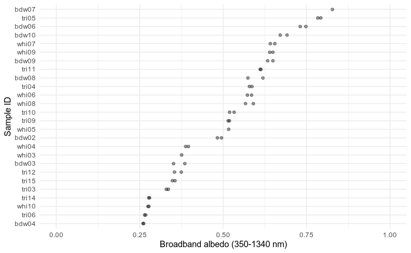

```r
albedo %>%
  mutate(sample_id = sample_id %>% str_remove("21.")) %>%
  ggplot(aes(x=  sample_id %>% fct_reorder(albedo), y = albedo )) +
  geom_point(alpha = 0.4) +
  labs(x = "Sample ID", y = "Broadband albedo (350-1340 nm)") +
  ylim(0,1) +
  coord_flip() +
  theme_minimal()
```

Seems reasonable. Use the mean value for the rest of this analysis

# Take mean values of everything

```r
albedo_wide <- albedo %>%
  group_by(sample_id) %>%
  summarise(mean_albedo = mean(albedo), sd_albedo = sd(albedo))
albedo_wide
```

| sample_id | mean_albedo | sd_albedo |
| --- | --- | --- |
| bdw21.02 | 0.4886616 | 0.008636988 |
| bdw21.03 | 0.3682618 | 0.023996093 |
| bdw21.04 | 0.2607727 | 0.001216234 |
| bdw21.06 | 0.7392645 | 0.012046949 |
| bdw21.07 | 0.8271889 | NA |
| bdw21.08 | 0.5966147 | 0.031739058 |
| bdw21.09 | 0.6412923 | 0.011250494 |
| bdw21.10 | 0.6812246 | 0.014465351 |
| tri21.03 | 0.3324643 | 0.004061833 |
| tri21.04 | 0.5824591 | 0.005311241 |

[output cut: 16 more lines]

```r
v_albedo_wide <- v_albedo %>%
  group_by(sample_id) %>%
  summarise(mean_vis_albedo = mean(albedo), sd_vis_albedo = sd(albedo))
v_albedo_wide
```

| sample_id | mean_vis_albedo | sd_vis_albedo |
| --- | --- | --- |
| bdw21.02 | 0.4799043 | 0.009234185 |
| bdw21.03 | 0.3237538 | 0.024973423 |
| bdw21.04 | 0.1973852 | 0.002642989 |
| bdw21.06 | 0.8148450 | 0.011941077 |
| bdw21.07 | 0.9838385 | NA |
| bdw21.08 | 0.6755640 | 0.037149471 |
| bdw21.09 | 0.7530310 | 0.012926279 |
| bdw21.10 | 0.8085662 | 0.017279716 |
| tri21.03 | 0.2560705 | 0.006663767 |
| tri21.04 | 0.6310541 | 0.006139292 |

[output cut: 16 more lines]

```r
nir_albedo_wide <- nir_albedo %>%
  group_by(sample_id) %>%
  summarise(mean_nir_albedo = mean(albedo), sd_nir_albedo = sd(albedo))

all_albedo <- left_join(albedo_wide, v_albedo_wide, by = "sample_id") %>%
  left_join(nir_albedo_wide, by = "sample_id")
all_albedo
```

| sample_id | mean_albedo | sd_albedo | mean_vis_albedo | sd_vis_albedo | mean_nir_albedo | sd_nir_albedo |
| --- | --- | --- | --- | --- | --- | --- |
| bdw21.02 | 0.4886616 | 0.008636988 | 0.4799043 | 0.009234185 | 0.5134975 | 0.0080933653 |
| bdw21.03 | 0.3682618 | 0.023996093 | 0.3237538 | 0.024973423 | 0.4360499 | 0.0235982421 |
| bdw21.04 | 0.2607727 | 0.001216234 | 0.1973852 | 0.002642989 | 0.3488619 | 0.0005870682 |
| bdw21.06 | 0.7392645 | 0.012046949 | 0.8148450 | 0.011941077 | 0.6649322 | 0.0125466975 |
| bdw21.07 | 0.8271889 | NA | 0.9838385 | NA | 0.6461255 | NA |
| bdw21.08 | 0.5966147 | 0.031739058 | 0.6755640 | 0.037149471 | 0.5130423 | 0.0254879284 |
| bdw21.09 | 0.6412923 | 0.011250494 | 0.7530310 | 0.012926279 | 0.5152985 | 0.0097085392 |
| bdw21.10 | 0.6812246 | 0.014465351 | 0.8085662 | 0.017279716 | 0.5352724 | 0.0115223941 |
| tri21.03 | 0.3324643 | 0.004061833 | 0.2560705 | 0.006663767 | 0.4387739 | 0.0011458805 |
| tri21.04 | 0.5824591 | 0.005311241 | 0.6310541 | 0.006139292 | 0.5374608 | 0.0043432078 |

[output cut: 16 more lines]

Make wide versions of cell count and RGND data

```r
cc_wide <- cc %>%
  pivot_wider(names_from= name, values_from = c("mean", "sd"))

rgnd_wide <- rgnd %>%
  filter(name=="rgnd") %>%
  select(-name) %>%
  rename(mean_rgnd = mean, sd_rgnd = sd)
```

Combine all data into a single data frame

```r
dirty_snow_samples <- c("bdw9", "whi10", "tri14")

# df containing all data used in this analysis
dat <- all_albedo %>%
  left_join(cc_wide) %>%
  left_join(rgnd_wide) %>%
  # shorten the sample ID for plotting
  mutate(sample_id = sample_id %>% str_remove("21.0"),# Remove the 21. from the sample IDs
         sample_id = sample_id %>% str_remove("21."),
         # annotate as "white" or "dirty" or "red" snow
         type = case_when(mean_cell_area_percent <0.01 ~ "white",
                          sample_id %in% dirty_snow_samples ~ "dirty",
                          TRUE ~ "red"))
dat
```

| sample_id | mean_albedo | sd_albedo | mean_vis_albedo | sd_vis_albedo | mean_nir_albedo | sd_nir_albedo | mean_bil_cells_per_sq_m | mean_cell_area_percent | mean_cell_cm2_per_l | sd_bil_cells_per_sq_m | sd_cell_area_percent | sd_cell_cm2_per_l | mean_rgnd | sd_rgnd | type |
| --- | --- | --- | --- | --- | --- | --- | --- | --- | --- | --- | --- | --- | --- | --- | --- |
| bdw2 | 0.4886616 | 0.008636988 | 0.4799043 | 0.009234185 | 0.5134975 | 0.0080933653 | 0.95492966 | 21.237238 | 133.43750 | 0.33761862 | 0.5486303 | 3.447146 | 0.2137480278 | 7.259154e-04 | red |
| bdw3 | 0.3682618 | 0.023996093 | 0.3237538 | 0.024973423 | 0.4360499 | 0.0235982421 | 1.00585924 | 47.956567 | 470.81250 | 0.05401898 | 0.5671993 | 5.568466 | 0.3167546499 | 6.298339e-03 | red |
| bdw4 | 0.2607727 | 0.001216234 | 0.1973852 | 0.002642989 | 0.3488619 | 0.0005870682 | 3.30071436 | 139.599496 | 1178.93750 | 0.31398532 | 1.7059869 | 14.407301 | 0.3681139085 | 7.807401e-03 | red |
| bdw6 | 0.7392645 | 0.012046949 | 0.8148450 | 0.011941077 | 0.6649322 | 0.0125466975 | NA | NA | NA | NA | NA | NA | 0.0832148903 | 2.278552e-03 | red |
| bdw7 | 0.8271889 | NA | 0.9838385 | NA | 0.6461255 | NA | 0.00000000 | 0.000000 | 0.00000 | 0.00000000 | 0.0000000 | 0.000000 | -0.0069161180 | NA | white |
| bdw8 | 0.5966147 | 0.031739058 | 0.6755640 | 0.037149471 | 0.5130423 | 0.0254879284 | 0.08482958 | 6.202348 | 59.40625 | 0.09380786 | 7.5226676 | 72.052308 | 0.0330774914 | 1.607869e-03 | red |
| bdw9 | 0.6412923 | 0.011250494 | 0.7530310 | 0.012926279 | 0.5152985 | 0.0097085392 | 0.00000000 | 0.000000 | 0.00000 | 0.00000000 | 0.0000000 | 0.000000 | 0.0005765586 | 3.735826e-04 | white |
| bdw10 | 0.6812246 | 0.014465351 | 0.8085662 | 0.017279716 | 0.5352724 | 0.0115223941 | 0.00000000 | 0.000000 | 0.00000 | 0.00000000 | 0.0000000 | 0.000000 | -0.0098094750 | 1.636195e-04 | white |
| tri3 | 0.3324643 | 0.004061833 | 0.2560705 | 0.006663767 | 0.4387739 | 0.0011458805 | 3.28973267 | 69.943027 | 422.56250 | 0.85774720 | 22.8796838 | 138.228167 | 0.3858625111 | 3.685110e-03 | red |
| tri4 | 0.5824591 | 0.005311241 | 0.6310541 | 0.006139292 | 0.5374608 | 0.0043432078 | 0.17507044 | 8.026980 | 57.31250 | 0.09903479 | 0.9532099 | 6.805903 | 0.0952351324 | 1.195810e-03 | red |

[output cut: 16 more lines]

# Compute IRF

For comparison with other studies (e.g Khan, Ganey)

Approach: multiply incoming solar radiation by delta albedo (mean white snow albedo)

Tidy the incident solar data

```r
scan2 <- scans %>% # SLOW
    # shorten the sample ID for plotting
  mutate(sample_id = sample_id %>% str_remove("21.0"),# Remove the 21. from the sample IDs
         sample_id = sample_id %>% str_remove("21.")) %>%
  group_by(sample_id, wvl) %>%
  summarise(mean = mean(tgt_ref_ratio),
            sd = sd(tgt_ref_ratio)) %>%
  ungroup()
```

get white snow mean albedo, to use as a baseline

| wvl | white_mean |
| --- | --- |
| 350 | 0.7763747 |
| 351 | 0.7765903 |
| 352 | 0.7769392 |
| 353 | 0.7773067 |
| 354 | 0.7776961 |
| 355 | 0.7780833 |
| 356 | 0.7783961 |
| 357 | 0.7786399 |
| 358 | 0.7787917 |
| 359 | 0.7789429 |

[output cut: 990 more lines]

compute how much the dirty and red snow reduce the albedo relative to white snow “delta albedo”

| sample_id | irf | irf_sd | mean_albedo | sd_albedo | mean_vis_albedo | sd_vis_albedo | mean_nir_albedo | sd_nir_albedo | mean_bil_cells_per_sq_m | mean_cell_area_percent | mean_cell_cm2_per_l | sd_bil_cells_per_sq_m | sd_cell_area_percent | sd_cell_cm2_per_l | mean_rgnd | sd_rgnd | type |
| --- | --- | --- | --- | --- | --- | --- | --- | --- | --- | --- | --- | --- | --- | --- | --- | --- | --- |
| bdw2 | 148.598357 | 6.6253562 | 0.4886616 | 0.008636988 | 0.4799043 | 0.009234185 | 0.5134975 | 0.0080933653 | 0.95492966 | 21.237238 | 133.43750 | 0.33761862 | 0.5486303 | 3.447146 | 0.21374803 | 0.0007259154 | red |
| bdw3 | 239.184042 | 18.1476740 | 0.3682618 | 0.023996093 | 0.3237538 | 0.024973423 | 0.4360499 | 0.0235982421 | 1.00585924 | 47.956567 | 470.81250 | 0.05401898 | 0.5671993 | 5.568466 | 0.31675465 | 0.0062983388 | red |
| bdw4 | 319.666743 | 1.5219861 | 0.2607727 | 0.001216234 | 0.1973852 | 0.002642989 | 0.3488619 | 0.0005870682 | 3.30071436 | 139.599496 | 1178.93750 | 0.31398532 | 1.7059869 | 14.407301 | 0.36811391 | 0.0078074010 | red |
| bdw6 | -39.544040 | 9.2389838 | 0.7392645 | 0.012046949 | 0.8148450 | 0.011941077 | 0.6649322 | 0.0125466975 | NA | NA | NA | NA | NA | NA | 0.08321489 | 0.0022785519 | red |
| bdw8 | 68.779859 | 23.8908336 | 0.5966147 | 0.031739058 | 0.6755640 | 0.037149471 | 0.5130423 | 0.0254879284 | 0.08482958 | 6.202348 | 59.40625 | 0.09380786 | 7.5226676 | 72.052308 | 0.03307749 | 0.0016078693 | red |
| tri10 | 119.186047 | 7.4871810 | 0.5260379 | 0.009802236 | 0.6105252 | 0.012913109 | 0.4373336 | 0.0062789123 | 0.05920564 | 5.039880 | 42.56250 | 0.04186471 | 3.6108311 | 30.493980 | 0.02517663 | 0.0027315251 | red |
| tri11 | 54.588820 | 1.4836787 | 0.6120237 | 0.001728501 | 0.6925237 | 0.001447116 | 0.5306630 | 0.0019480607 | 0.06604930 | 2.737744 | 25.90625 | 0.05499703 | 3.0034814 | 28.420828 | 0.04494470 | 0.0003366743 | red |
| tri12 | 242.325572 | 11.0761572 | 0.3642002 | 0.014514120 | 0.3780874 | 0.017151746 | 0.3556802 | 0.0116397610 | 0.37823172 | 16.769560 | 135.78125 | 0.10508449 | 5.6996287 | 46.149257 | 0.12933831 | 0.0075515654 | red |
| tri13 | 211.852088 | 38.8803981 | NA | NA | NA | NA | NA | NA | NA | NA | NA | NA | NA | NA | NA | NA | NA |
| tri14 | 307.194410 | 2.0375878 | 0.2781561 | 0.001789634 | 0.2826688 | 0.003842234 | 0.2801922 | 0.0006162188 | 0.49377821 | 21.864905 | 202.03125 | 0.17306896 | 6.2753639 | 57.984227 | 0.14738660 | 0.0054910559 | dirty |

[output cut: 12 more lines]

# plot

## plot template function

```r
my_plot <- function(dat, x, y, xsd, ysd, formula){
  x <- enquo(x)
  y <- enquo(y)
  xsd <- enquo(xsd)
  ysd <- enquo(ysd)

  dat %>%
    ggplot(aes(y = !!y, x = !!x)) +
    geom_smooth(method = "lm", se = FALSE, formula = formula, data = dat %>% filter(type=="red"), color = "#F8766D") +
    geom_point(aes(fill = type), color="black", pch = 21, size = 2.4) +
    # the Y axis SD crossbar
    geom_linerange(aes(ymin = !!y - !!ysd,
                        ymax = !!y + !!ysd),
                        alpha = 0.4) +
    # the X axis crossbar
    geom_linerange(aes(xmin = !!x - !!xsd,
                     xmax = !!x + !!xsd),
                  alpha = 0.4) +
    theme_minimal()
}
```

## A. albedo vs algae abund

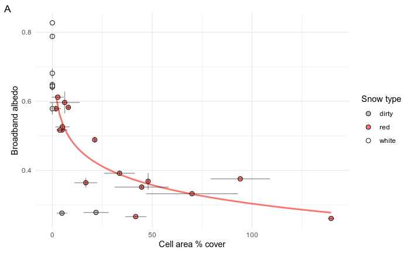

```r
pa <- my_plot(dat, x = mean_cell_area_percent, y = mean_albedo, xsd = sd_cell_area_percent, ysd = sd_albedo, formula = y~log(x)) +
  labs(x = "Cell area % cover", y = "Broadband albedo", fill = "Snow type", tag = "A") +
  # lims(y = c(0, 1)) +
  scale_fill_manual(values = c("gray", "#F8766D", "white"))
pa
```

## B albedo vs RGND

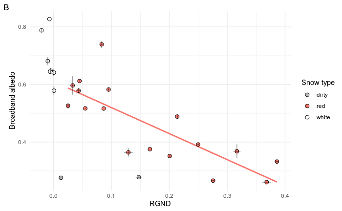

```r
pb <- my_plot(dat, x = mean_rgnd, y = mean_albedo, xsd = sd_rgnd, ysd = sd_albedo, formula = y~x) +
  labs(x = "RGND", y = "Broadband albedo", fill = "Snow type", tag = "B") +
  # lims(y = c(0, 1)) +
  scale_fill_manual(values = c("gray", "#F8766D", "white"))
pb
```

## C. algae abund vs IRF

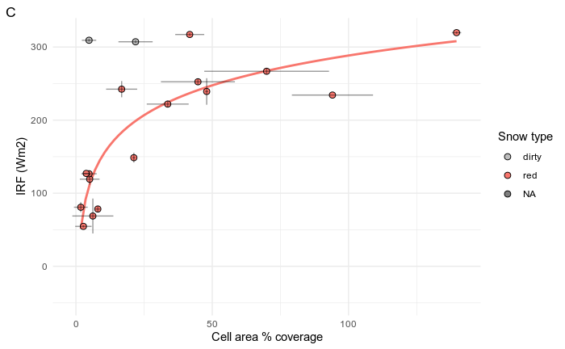

```r
pc <- my_plot(irf_full, x = mean_cell_area_percent, y = irf, xsd = sd_cell_area_percent, ysd = irf_sd, formula = y~log(x)) +
  labs(y = "IRF (Wm2)", x = "Cell area % coverage", fill = "Snow type", tag = "C") +
  scale_fill_manual(values = c("gray", "#F8766D"))
pc
```

## Combine panels (Fig 3)

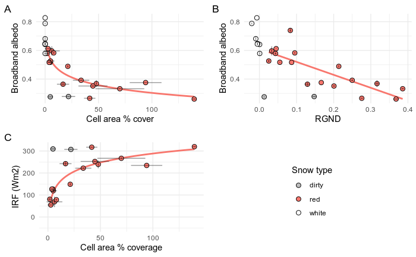

```r
legend <- cowplot::get_legend(pa)
ggarrange(pa + theme(legend.position = "none"),
          pb + theme(legend.position = "none"),
          pc + theme(legend.position = "none"),
          legend,
          ncol = 2, nrow = 2)
```

```r
# ggsave(here("figs/f3.pdf"))
```

# Regression coefficients

| sample_id | mean_albedo | sd_albedo | mean_vis_albedo | sd_vis_albedo | mean_nir_albedo | sd_nir_albedo | mean_bil_cells_per_sq_m | mean_cell_area_percent | mean_cell_cm2_per_l | sd_bil_cells_per_sq_m | sd_cell_area_percent | sd_cell_cm2_per_l | mean_rgnd | sd_rgnd | type |
| --- | --- | --- | --- | --- | --- | --- | --- | --- | --- | --- | --- | --- | --- | --- | --- |
| bdw2 | 0.4886616 | 0.008636988 | 0.4799043 | 0.009234185 | 0.5134975 | 0.0080933653 | 0.95492966 | 21.237238 | 133.43750 | 0.33761862 | 0.5486303 | 3.447146 | 0.21374803 | 0.0007259154 | red |
| bdw3 | 0.3682618 | 0.023996093 | 0.3237538 | 0.024973423 | 0.4360499 | 0.0235982421 | 1.00585924 | 47.956567 | 470.81250 | 0.05401898 | 0.5671993 | 5.568466 | 0.31675465 | 0.0062983388 | red |
| bdw4 | 0.2607727 | 0.001216234 | 0.1973852 | 0.002642989 | 0.3488619 | 0.0005870682 | 3.30071436 | 139.599496 | 1178.93750 | 0.31398532 | 1.7059869 | 14.407301 | 0.36811391 | 0.0078074010 | red |
| bdw6 | 0.7392645 | 0.012046949 | 0.8148450 | 0.011941077 | 0.6649322 | 0.0125466975 | NA | NA | NA | NA | NA | NA | 0.08321489 | 0.0022785519 | red |
| bdw8 | 0.5966147 | 0.031739058 | 0.6755640 | 0.037149471 | 0.5130423 | 0.0254879284 | 0.08482958 | 6.202348 | 59.40625 | 0.09380786 | 7.5226676 | 72.052308 | 0.03307749 | 0.0016078693 | red |
| tri3 | 0.3324643 | 0.004061833 | 0.2560705 | 0.006663767 | 0.4387739 | 0.0011458805 | 3.28973267 | 69.943027 | 422.56250 | 0.85774720 | 22.8796838 | 138.228167 | 0.38586251 | 0.0036851096 | red |
| tri4 | 0.5824591 | 0.005311241 | 0.6310541 | 0.006139292 | 0.5374608 | 0.0043432078 | 0.17507044 | 8.026980 | 57.31250 | 0.09903479 | 0.9532099 | 6.805903 | 0.09523513 | 0.0011958098 | red |
| tri6 | 0.2661562 | 0.002279735 | 0.2379566 | 0.001412625 | 0.3096732 | 0.0033571096 | 1.58279591 | 41.736394 | 364.21875 | 0.14490094 | 5.3166781 | 46.396769 | 0.27563239 | 0.0035277440 | red |
| tri9 | 0.5168801 | 0.002709952 | 0.5729273 | 0.002982434 | 0.4621683 | 0.0025231687 | 0.12254931 | 4.805684 | 34.31250 | 0.02475870 | 2.8101123 | 20.064155 | 0.05492817 | 0.0003271173 | red |
| tri10 | 0.5260379 | 0.009802236 | 0.6105252 | 0.012913109 | 0.4373336 | 0.0062789123 | 0.05920564 | 5.039880 | 42.56250 | 0.04186471 | 3.6108311 | 30.493980 | 0.02517663 | 0.0027315251 | red |

[output cut: 7 more lines]

## A. albedo vs algae area

| term | estimate | std.error | statistic | p.value |
| --- | --- | --- | --- | --- |
| (Intercept) | 0.66237994 | 0.03260054 | 20.318064 | 8.681790e-12 |
| log(mean_cell_area_percent) | -0.07790999 | 0.01057870 | -7.364799 | 3.538532e-06 |

Compute 95% CI

```r
1.96*0.032
```

```
[1] 0.06272
```

albedo = (0.66 +/- 0.063) - 0.08 +/- 0.0207 * log(Cell Area Percent Cover)

```r
summary(albedo_algae_mod)$r.squared # .80
```

```
[1] 0.7948425
```

##B. albedo vs RGND

```r
albedo_rgnd_mod <- lm(mean_albedo ~ mean_rgnd, data = mod_dat)
tidy(albedo_rgnd_mod)
```

| term | estimate | std.error | statistic | p.value |
| --- | --- | --- | --- | --- |
| (Intercept) | 0.6102463 | 0.03468248 | 17.595234 | 2.001491e-11 |
| mean_rgnd | -0.9038061 | 0.17268085 | -5.233969 | 1.009818e-04 |

95% CI

```r
1.96*0.03468
```

```
[1] 0.0679728
```

```r
1.96*0.1726
```

```
[1] 0.338296
```

Excluding the intercept, the delta albedo attributable to algae is predicted by: delta_albedo = 0.9 +/- 0.34 RGND

```r
summary(albedo_rgnd_mod)$r.squared # 0.6
```

```
[1] 0.6461799
```

## C. IRF vs algae area

| term | estimate | std.error | statistic | p.value |
| --- | --- | --- | --- | --- |
| log(mean_cell_area_percent) | 63.92734 | 3.351864 | 19.07218 | 6.27258e-12 |

95% CI

```r
1.96*3.35
```

```
[1] 6.566
```

```r
summary(irf_mod)$r.squared
```

```
[1] 0.9603958
```

sanity check

```r
log(100)*59
```

```
[1] 271.705
```

# compare IRF with Ganey, Khan

compute a 350-850 nm IRF for direct comparison with Ganey, Khan

```r
irf2 <- irfs %>%
  filter(wvl>=350, wvl<=850) %>%
  group_by(sample_id) %>%
  summarise(irf = sum(irf),
            irf_sd = sum(irf_sd)) %>%
  left_join(dat) %>%  # cell abundance metrics
  ungroup()
```

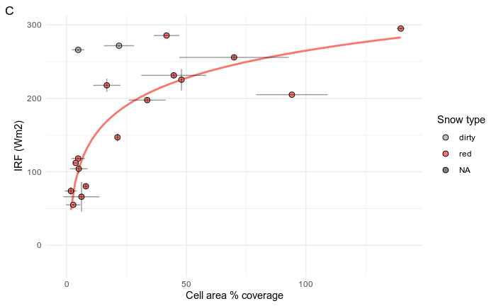

```r
my_plot(irf2, x = mean_cell_area_percent, y = irf, xsd = sd_cell_area_percent, ysd = irf_sd, formula = y~log(x)) +
  labs(y = "IRF (Wm2)", x = "Cell area % coverage", fill = "Snow type", tag = "C") +
  scale_fill_manual(values = c("gray", "#F8766D"))
```

Very similar to our full albedo IRF (the NIR does not contribute much)

# Categorical comparison red, white, dirty snow

## mean values for BB, visible, NIR albedo

```r
dat %>%
  select(type, contains("mean")) %>%
  group_by(type) %>%
  summarise_all(mean)
```

[output not shown]

## plot

```r
dat %>%
  # format for plotting
  select(type, mean_cell_area_percent, mean_albedo, mean_vis_albedo, mean_nir_albedo) %>%
  pivot_longer(cols = c(mean_albedo, mean_vis_albedo, mean_nir_albedo)) %>%
  ggplot(aes(y = value, x = type)) +
  facet_grid(rows = vars(name)) +
  geom_boxplot() +
  # geom_jitter(width = 0.2) +
  lims(y = c(0,1)) +
  labs(y = "Broadband albedo (350 - 1340 nm)") +
  theme_minimal()
```

[output not shown]

## NIR albedo white vs red ANOVA

```r
# anova
nir_mod <- lm(mean_nir_albedo~type, data = dat %>% filter(type!="dirty"))
summary(nir_mod)
```

[output not shown]